# HDAT9600 Final Assignment Data Preparation Details

Tim Churches

05/10/2018

## Introduction

This R Markdown document provides details of how the data which is to be used for the HDAT9600 course final assignment was created. You should familiarise yourself with the contents of this document as background to the assignment. However, you are strongly recommended **not** to re-run this document to re-create the data. The data have already been provided as R data files (*.rds files), as described in the assignment document. However, all the files needed to reproduce the data preparation process have been provided.

## Source data

The source data for the assignment are data made freely available for the 2012 MIT PhysioNet/Computing for Cardiology Challenge. Details are provided [here](https://physionet.org/challenge/2012/). Training Set A data have been used.

The description of the **source** data is as follows. Note that these source data have been transformed using the R code shown below, and thus the following descriptions need to be considered with that subsequent processing in mind:

> The data used for the challenge consist of records from 12,000 ICU stays. All patients were adults who were admitted for a wide variety of reasons to cardiac, medical, surgical, and trauma ICUs [in the US]. ICU stays of less than 48 hours have been excluded. Patients with DNR (do not resuscitate) or CMO (comfort measures only) directives were **not** excluded.

> Four thousand records comprise training set A. Outcomes are provided for the training set records in a separate file.

> Up to 42 variables were recorded at least once during the first 48 hours after admission to the ICU. Not all variables are available in all cases, however. Six of these variables are general descriptors (collected on admission), and the remainder are time series, for which multiple observations may be available.

> Each observation has an associated time-stamp indicating the elapsed time of the observation since ICU admission in each case, in hours and minutes. Thus, for example, a time stamp of 35:19 means that the associated observation was made 35 hours and 19 minutes after the patient was admitted to the ICU.

> Each record is stored as a comma-separated value (CSV) text file.

> All valid values for general descriptors, time series variables, and outcome-related descriptors are non-negative (≥ 0). A value of -1 indicates missing or unknown data (for example, if a patient’s height was not recorded).

> General Descriptors

> As noted, these six descriptors are collected at the time the patient is admitted to the ICU. Their associated time-stamps are set to 00:00 (thus they appear at the beginning of each patient’s record): * RecordID (a unique integer for each ICU stay) * Age (years) * Gender (0: female, or 1: male) * Height (cm) * ICUType (1: Coronary Care Unit, 2: Cardiac Surgery Recovery Unit, 3: Medical ICU, or 4: Surgical ICU) * Weight (kg)

> Time Series variables

> These 37 variables may be observed once, more than once, or not at all in some cases:
> - [*Albumin*](http://en.wikipedia.org/wiki/Human_serum_albumin) (g/dL)
> - [*ALP*](http://en.wikipedia.org/wiki/Alkaline_phosphatase) [Alkaline phosphatase (IU/L)]
> - [*ALT*](http://en.wikipedia.org/wiki/Alanine_transaminase) [Alanine transaminase (IU/L)]
> - [*AST*](http://en.wikipedia.org/wiki/Aspartate_transaminase) [Aspartate transaminase (IU/L)]
> - [*Bilirubin*](http://en.wikipedia.org/wiki/Bilirubin) (mg/dL)
> - [*BUN*](http://en.wikipedia.org/wiki/BUN) [Blood urea nitrogen (mg/dL)]
> - [*Cholesterol*](http://en.wikipedia.org/wiki/Cholesterol) (mg/dL)
> - [*Creatinine*](http://en.wikipedia.org/wiki/Serum_creatinine#Plasma_creatinine) [Serum creatinine (mg/dL)]
> - [*DiasABP*](http://en.wikipedia.org/wiki/Diastolic_blood_pressure) [Invasive diastolic arterial blood pressure (mmHg)]
> - [*FiO2*](http://en.wikipedia.org/wiki/FIO2) [Fractional inspired O<sub>2</sub> (0-1)]
> - [*GCS*](http://en.wikipedia.org/wiki/Glasgow_coma_score) [Glasgow Coma Score (3-15)]
> - [*Glucose*](http://en.wikipedia.org/wiki/Serum_glucose) [Serum glucose (mg/dL)]
> - [*HCO3*](http://en.wikipedia.org/wiki/Bicarbonate#Diagnostics) [Serum bicarbonate (mmol/L)]
> - [*HCT*](http://en.wikipedia.org/wiki/Hematocrit) [Hematocrit (%)]
> - [*HR*](http://en.wikipedia.org/wiki/Heart_rate) [Heart rate (bpm)]
> - [*K*](http://en.wikipedia.org/wiki/Hypokalemia) [Serum potassium (mEq/L)]
> - [*Lactate*](http://en.wikipedia.org/wiki/Lactic_acid) (mmol/L)
> - [*Mg*](http://en.wikipedia.org/wiki/Magnesium#Biological_role) [Serum magnesium (mmol/L)]
> - [*MAP*](http://en.wikipedia.org/wiki/Mean_arterial_pressure) [Invasive mean arterial blood pressure (mmHg)]
> - [*MechVent*](http://en.wikipedia.org/wiki/Mechanical_ventilation) [Mechanical ventilation respiration (0:false, or 1:true)]
> - [*Na*](http://en.wikipedia.org/wiki/Serum_sodium) [Serum sodium (mEq/L)]
> - [*NIDiasABP*](http://en.wikipedia.org/wiki/Diastolic_blood_pressure) [Non-invasive diastolic arterial blood pressure (mmHg)]
> - [*NIMAP*](http://en.wikipedia.org/wiki/Mean_arterial_pressure) [Non-invasive mean arterial blood pressure (mmHg)]
> - [*NISysABP*](http://en.wikipedia.org/wiki/Systolic_blood_pressure) [Non-invasive systolic arterial blood pressure (mmHg)]
> - [*PaCO2*](http://en.wikipedia.org/wiki/Arterial_blood_gas) [partial pressure of arterial CO<sub>2</sub> (mmHg)]
> - [*PaO2*](http://en.wikipedia.org/wiki/Arterial_blood_gas) [Partial pressure of arterial O<sub>2</sub> (mmHg)]
> - [*pH*](http://en.wikipedia.org/wiki/Arterial_blood_gas) [Arterial pH (0-14)]
> - [*Platelets*](http://en.wikipedia.org/wiki/Platelets) (cells/nL)
> - [*RespRate*](http://en.wikipedia.org/wiki/Respiratory_physiology) [Respiration rate (bpm)]
> - [*SaO2*](http://en.wikipedia.org/wiki/Arterial_blood_gas) [O<sub>2</sub> saturation in hemoglobin (%)]
> - [*SysABP*](http://en.wikipedia.org/wiki/Systolic_blood_pressure) [Invasive systolic arterial blood pressure (mmHg)]
> - [*Temp*](http://en.wikipedia.org/wiki/Normal_human_body_temperature) [Temperature (°C)]
> - [*TropI*](http://en.wikipedia.org/wiki/Troponin) [Troponin-I (μg/L)]
> - [*TropT*](http://en.wikipedia.org/wiki/Troponin) [Troponin-T (μg/L)]
> - [*Urine*](http://en.wikipedia.org/wiki/Fluid_balance) [Urine output (mL)]
> - [*WBC*](http://en.wikipedia.org/wiki/Reference_ranges_for_blood_tests#Hematology) [White blood cell count (cells/nL)]
> - *Weight* (kg)

> The time series measurements are recorded in chronological order within each record, and the associated time stamps indicate the elapsed time since admission to the ICU. Measurements may be recorded at regular intervals ranging from hourly to daily, or at irregular intervals as required. Not all time series are available in all cases.

> In a few cases, such as blood pressure, different measurements made using two or more methods or sensors may be recorded with the same or only slightly different time-stamps. Occasional outliers should be expected as well.

> Note that *Weight* is both a general descriptor (recorded on admission) and a time series variable (often measured hourly, for estimating fluid balance).

> Outcome-related Descriptors

> The outcome-related descriptors are kept in a separate CSV text file for each of the three record sets; as noted, only the file associated with training set A is available to participants. Each line of the outcomes file contains these descriptors:
> - *RecordID* (defined as above)
> - *SAPS-I score* ([Le Gall et al., 1984](http://www.ncbi.nlm.nih.gov/pubmed/6499483))
> - *SOFA score* ([Ferreira et al., 2001](http://www.ncbi.nlm.nih.gov/pubmed/11594901))
> - *Length of stay* (days)
> - *Survival* (days)
> - *In-hospital death* (0: survivor, or 1: died in-hospital)

Note that the SAPS-I and SOFA scores are summary predictor scores (that you may wish to use in your models) — they are **not** outcome variables, despite being supplied in the outcomes data file.

> The *Length of stay* is the number of days between the patient’s admission to the ICU and the end of hospitalization (including any time spent in the hospital after discharge from the ICU). If the patient’s death was recorded (in or out of hospital), then *Survival* is the number of days between ICU admission and death; otherwise, *Survival* is assigned the value -1. Since patients who spent less than 48 hours in the ICU have been excluded, *Length of stay* and *Survival* never have the values 0 or 1 in the data sets. Given these definitions and constraints, the following rules apply:

> *Survival* > *Length of stay* ⇒ Survivor  
> *Survival* = -1 ⇒ Survivor  
> 2 ≤ *Survival* ≤ *Length of stay* ⇒ In-hospital death

## Data preparation

In order to make the source data easier to use for the purposes of this final assignment, the following transformation and data preparation steps have been carried out. Each stage is explained in detail in the comments embedded in the code.

### Stage 1 - read the data into R

```r
# load required libraries
library(tidyverse)
library(magrittr)

# read the outcomes CSV file
outcomes <- read_csv("raw-data/outcomes-a.txt")

# create a vector of all the files names for the individual patient data files
file_list <- list.files("raw-data/set-a/", full.names = TRUE)

# define the column specifications for reading the data from each patient file
colspec <- cols(
  Time = col_character(),
  Parameter = col_character(),
  Value = col_double()
)

# initialise counter
n <- 1

# remove existing data frame if present
if(exists("events")) rm(events)

# loop through each patient file
for (file in file_list){
  # print a progress message
  if (n %% 100 == 0) print(n)
  # read the patient data file into temp_events data frame
  temp_events <-read_csv(file, col_types = colspec)
  # get the RecordID
  RecordID <- as.integer(temp_events[temp_events$Parameter == "RecordID",]$Value)
  # add it as a column to all rows of the data frame
  temp_events$RecordID <- RecordID
  # remove the RecordID row from the data frame
  temp_events <- temp_events[temp_events$Parameter != "RecordID",]
  # if the merged dataset doesn't exist, create it
  if (!exists("events")){
    events <- temp_events
  } else {
    # if the merged dataset does exist, append to it
    events <- bind_rows(events, temp_events)
  }
  # cleean up the temporary data frame
  rm(temp_events)
  # increment the loop counter
  n <- n + 1
}
```

```
## [1] 100
## [1] 200
## [1] 300
## [1] 400
## [1] 500
## [1] 600
## [1] 700
## [1] 800
## [1] 900
## [1] 1000
## [1] 1100
## [1] 1200
## [1] 1300
## [1] 1400
## [1] 1500
## [1] 1600
## [1] 1700
## [1] 1800
## [1] 1900
## [1] 2000
```

### Stage 2 - subset the data to the first 24 hours

The goal here is to keep to only those measurements/values for the first 24 hours in ICU for each patient.

```r
# from the events data frame
events_first_24hrs <- events %>%
          # first split the character Time value into numeric hours and minutes parts
          separate(Time, c("ts_hours", "ts_minutes"), sep = ":", convert=TRUE) %>%
          # derive a time offset variable in minutes from hours and minutes
          mutate(toffset = ts_hours*60 + ts_minutes) %>%
          # remove the non-longer-needed hours and minutes columns
          select(-ts_hours, -ts_minutes) %>%
          # retain rows only for the first 24 hrs in ICU
          filter(toffset <= 60*24)
```

### Stage 3 - check the data

The goal in this stage is to check univariate summary statistics and to visualise a histogram for each *Parameter* (that is, measurement/value type (**not** “parameter estimate” as in a statistical model) in the data, **before** we “roll up” the data into one row per patient. Currently those data are in “long, thin” format with one row per patient per *Parameter* per time point (in the first 24 hours in ICU), and in that form it is much easier to assess the distribution of all values for each patient for each *Parameter*.

```r
# the events_first_24hrs data frame has one row per Parameter (variable) per time point per patient
# so, define a function to print summary statistics and draw a histogram for each
# Parameter in the data frame
check <- function(varname) {
  a <- events_first_24hrs %>% filter(Parameter == varname) %>%
        rename(!!varname := Value)
  print(summary(a[varname]))
  ggplot(a, aes_string(x=varname)) + geom_histogram() + ggtitle(varname)
}

# then call the function on each Parameter in the data frame
```

```r
check("Age")
```

```
##       Age
##  Min.   :16.00
##  1st Qu.:52.00
##  Median :67.00
##  Mean   :64.41
##  3rd Qu.:78.00
##  Max.   :90.00
```

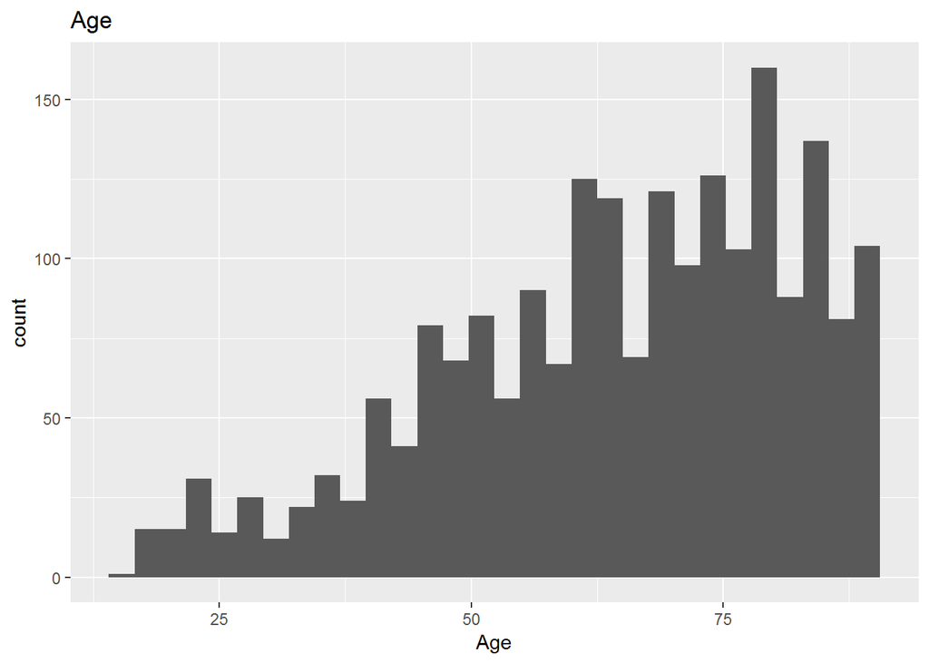

```r
check("Gender")
```

```
##      Gender
##  Min.   :-1.0000
##  1st Qu.: 0.0000
##  Median : 1.0000
##  Mean   : 0.5556
##  3rd Qu.: 1.0000
##  Max.   : 1.0000
```

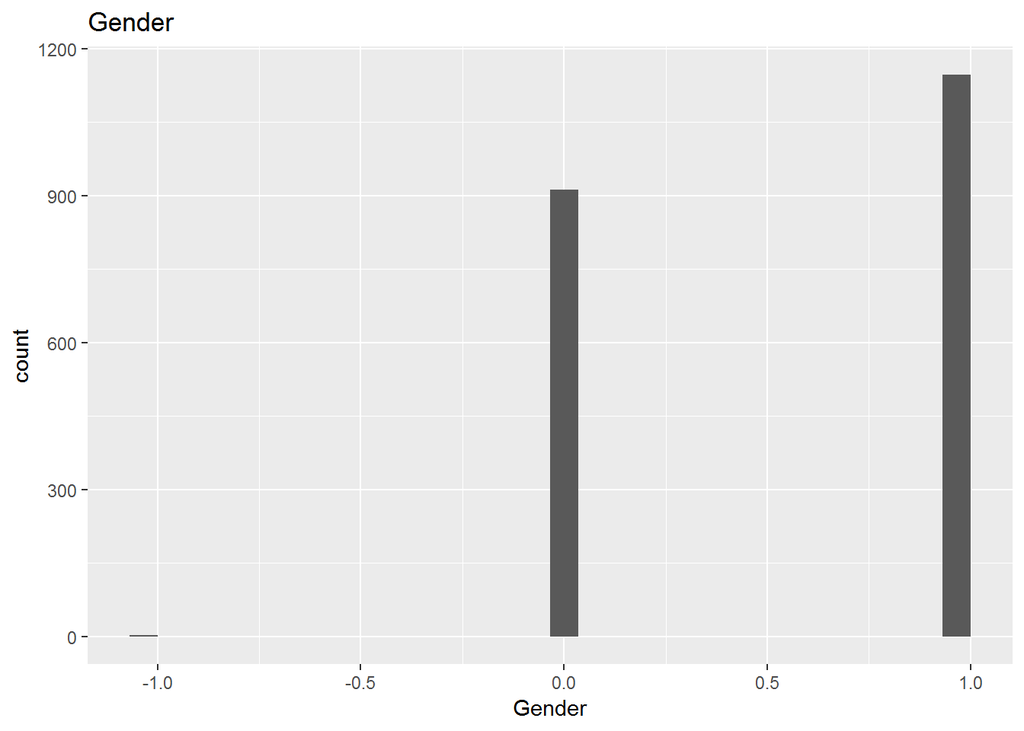

```r
check("Height")
```

```
##      Height
##  Min.   : -1.00
##  1st Qu.: -1.00
##  Median :152.40
##  Mean   : 87.68
##  3rd Qu.:170.20
##  Max.   :426.70
```

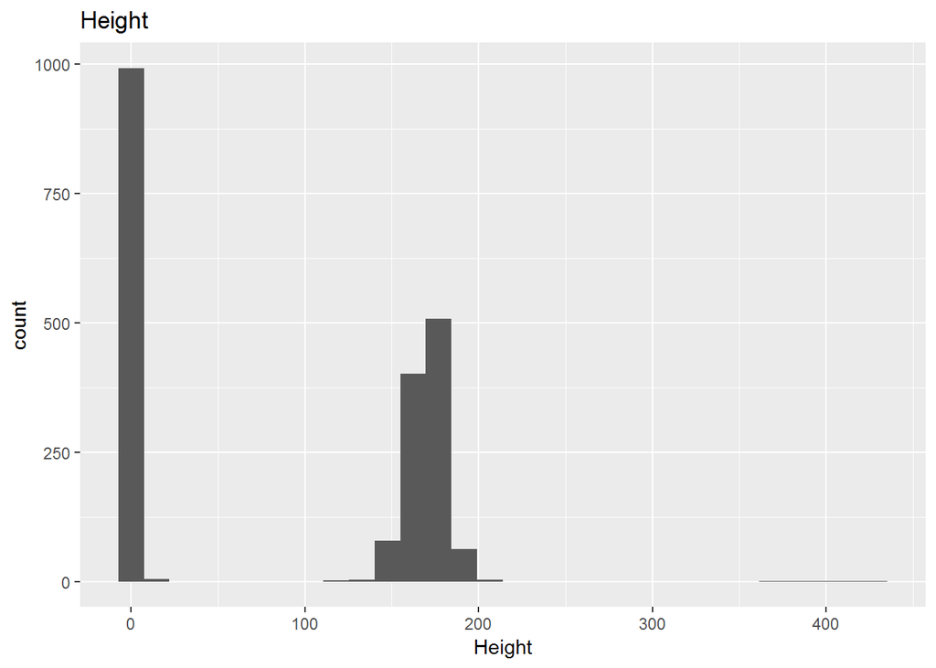

```r
check("ICUType")
```

```
##     ICUType
##  Min.   :1.000
##  1st Qu.:2.000
##  Median :3.000
##  Mean   :2.751
##  3rd Qu.:4.000
##  Max.   :4.000
```

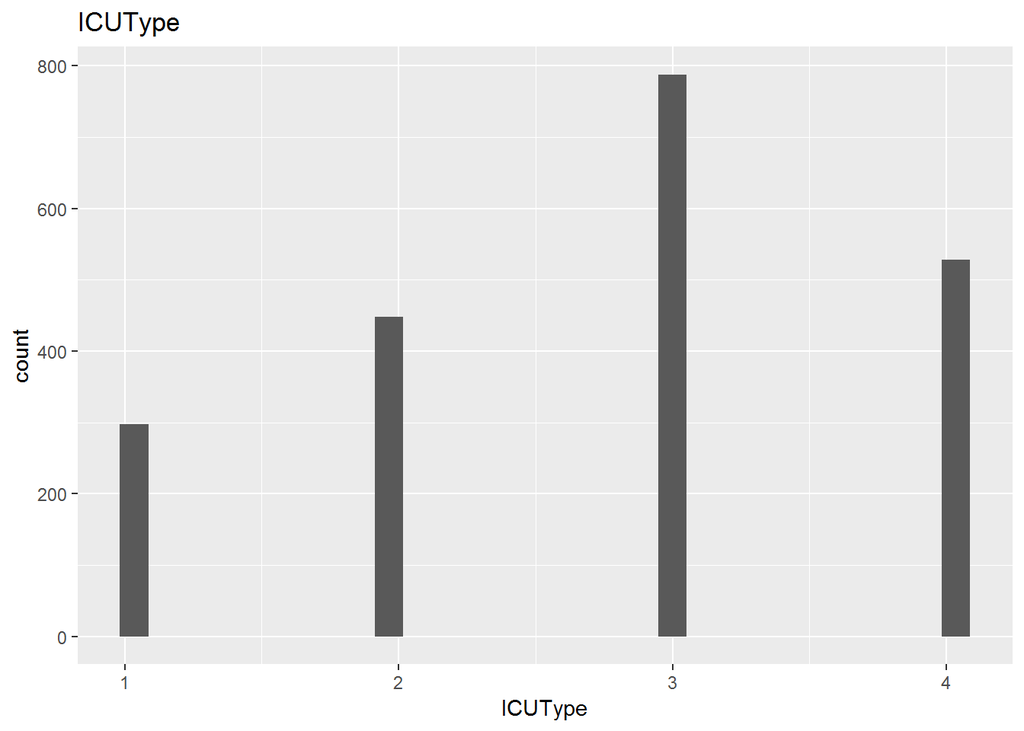

```r
check("Weight")
```

```
##      Weight
##  Min.   : -1.00
##  1st Qu.: 65.50
##  Median : 79.20
##  Mean   : 81.71
##  3rd Qu.: 94.60
##  Max.   :230.00
```

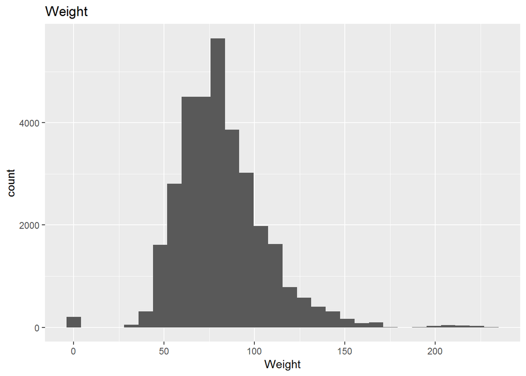

```r
check("GCS")
```

```
##       GCS
##  Min.   : 3.00
##  1st Qu.: 8.00
##  Median :11.00
##  Mean   :11.02
##  3rd Qu.:15.00
##  Max.   :15.00
```

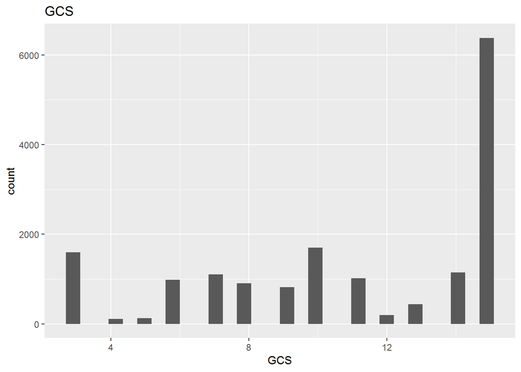

```r
check("HR")
```

```
##        HR
##  Min.   :  0.00
##  1st Qu.: 75.00
##  Median : 87.00
##  Mean   : 87.65
##  3rd Qu.: 99.00
##  Max.   :300.00
```

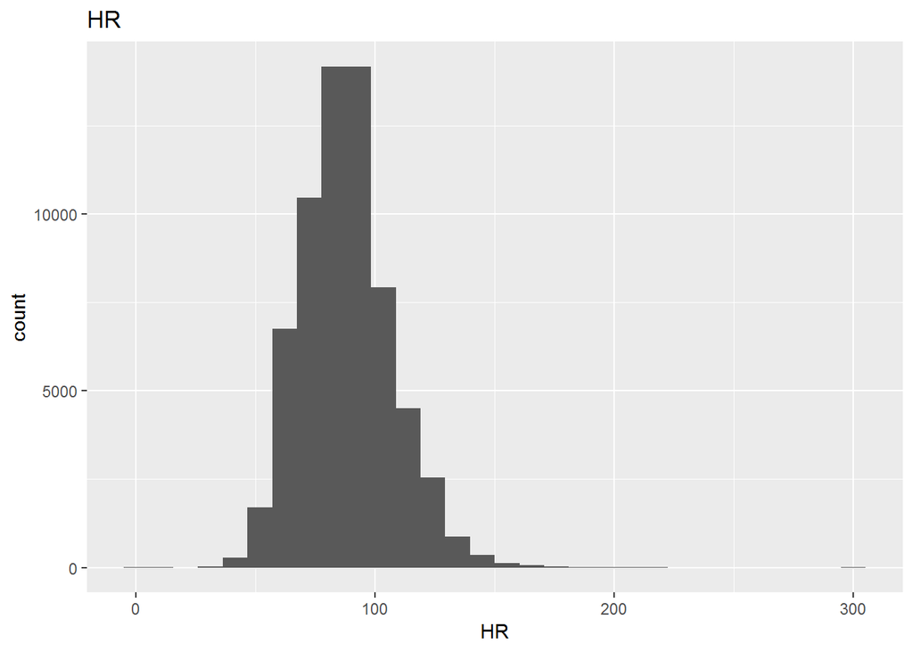

```r
check("NIDiasABP")
```

```
##    NIDiasABP
##  Min.   :  0.0
##  1st Qu.: 47.0
##  Median : 56.0
##  Mean   : 57.9
##  3rd Qu.: 68.0
##  Max.   :174.0
```

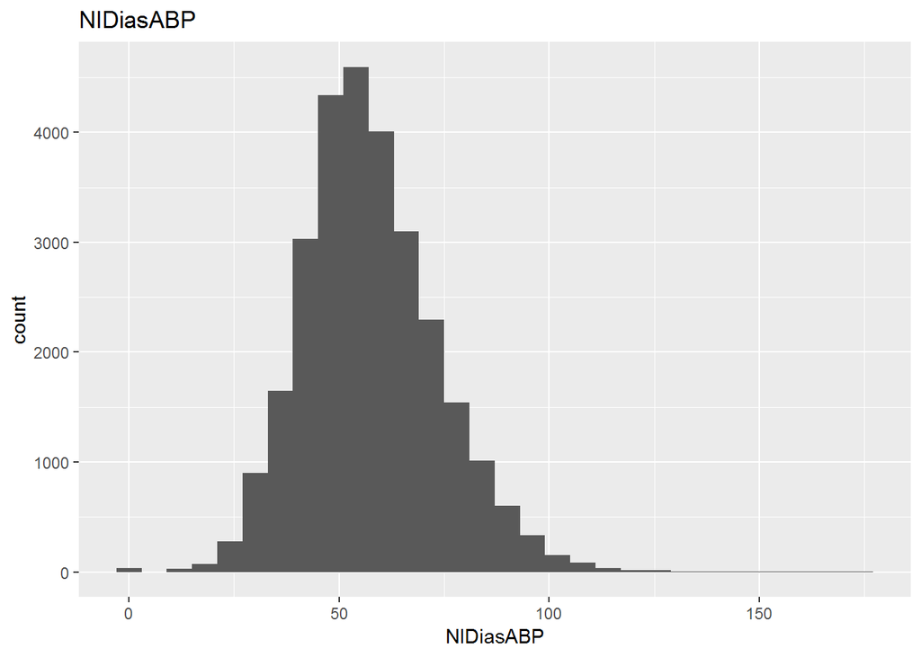

```r
check("NIMAP")
```

```
##      NIMAP
##  Min.   :  0.00
##  1st Qu.: 65.00
##  Median : 74.33
##  Mean   : 76.26
##  3rd Qu.: 86.00
##  Max.   :189.00
```

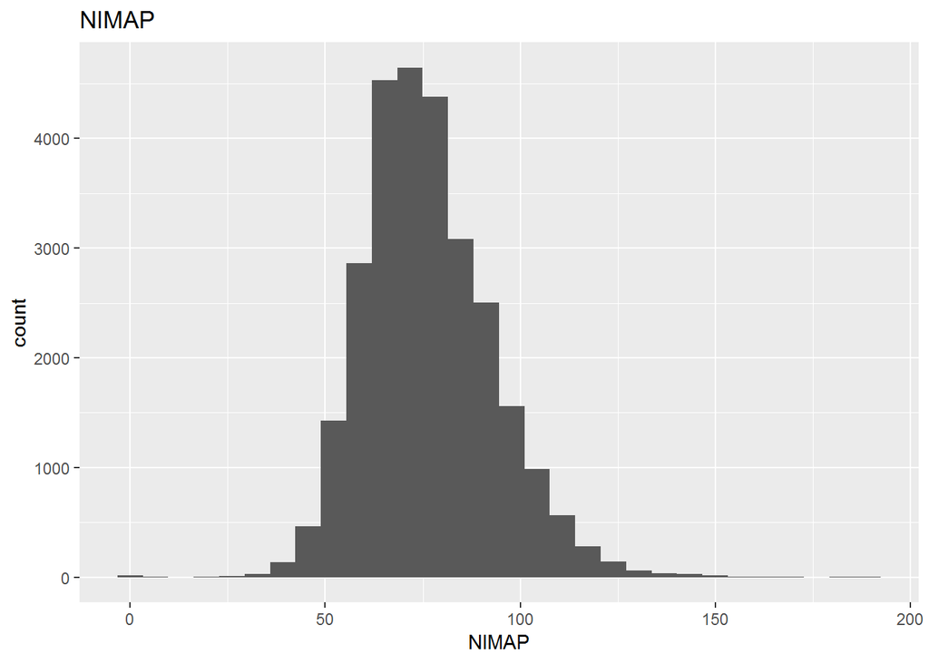

```r
check("NISysABP")
```

```
##     NISysABP
##  Min.   :  0.0
##  1st Qu.:100.0
##  Median :115.0
##  Mean   :117.5
##  3rd Qu.:132.0
##  Max.   :274.0
```

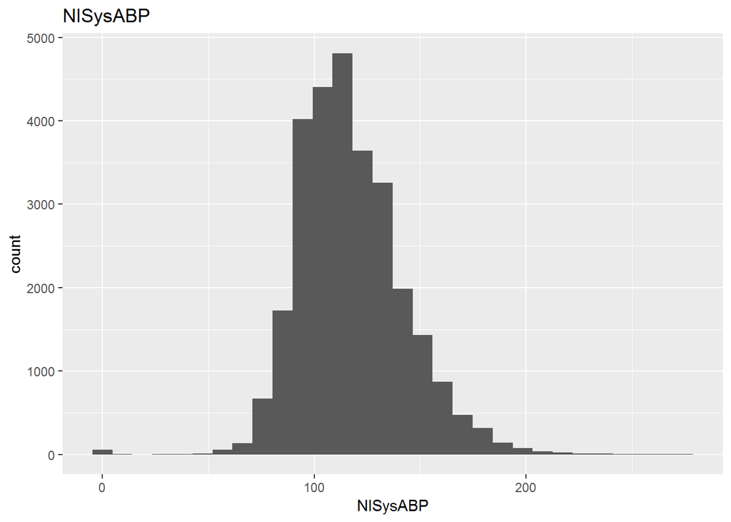

```r
check("RespRate")
```

```
##     RespRate
##  Min.   : 0.00
##  1st Qu.:16.00
##  Median :19.00
##  Mean   :19.58
##  3rd Qu.:23.00
##  Max.   :98.00
```

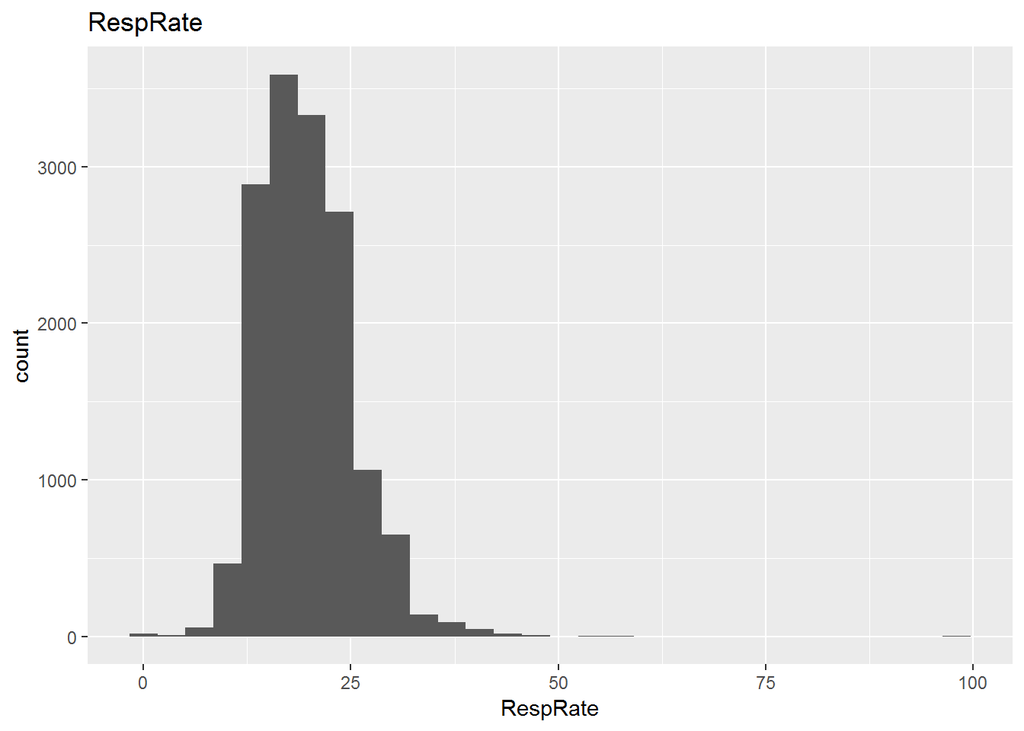

```r
check("Temp")
```

```
##       Temp
##  Min.   :-17.8
##  1st Qu.: 36.4
##  Median : 37.0
##  Mean   : 36.9
##  3rd Qu.: 37.6
##  Max.   : 42.1
```

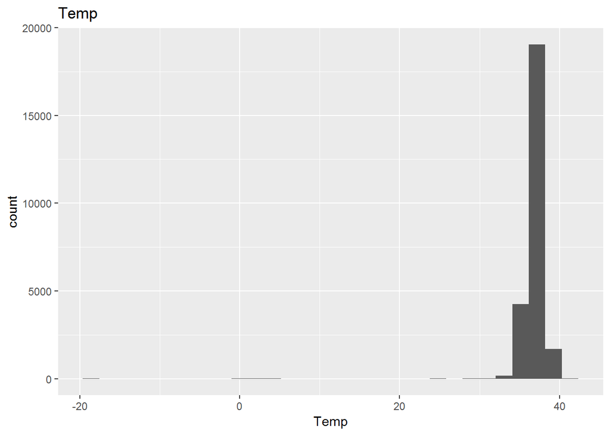

```r
check("Urine")
```

```
##      Urine
##  Min.   :   0.0
##  1st Qu.:  35.0
##  Median :  70.0
##  Mean   : 124.9
##  3rd Qu.: 140.0
##  Max.   :5000.0
```

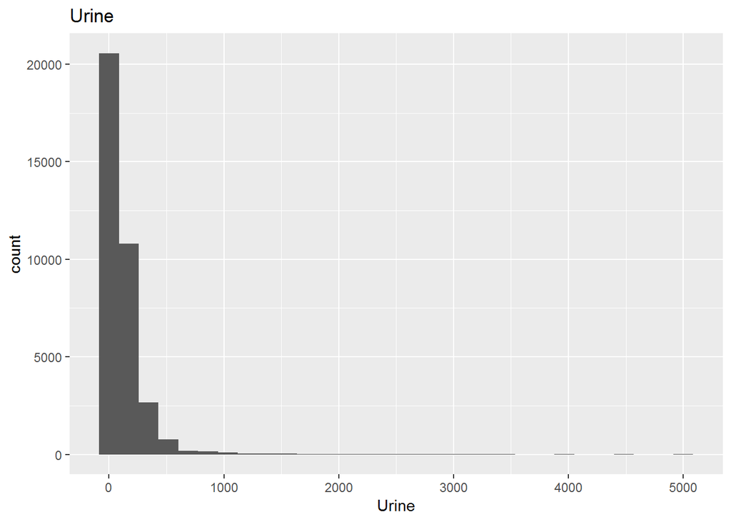

```r
check("HCT")
```

```
##       HCT
##  Min.   : 9.00
##  1st Qu.:27.60
##  Median :30.60
##  Mean   :31.06
##  3rd Qu.:34.20
##  Max.   :54.40
```

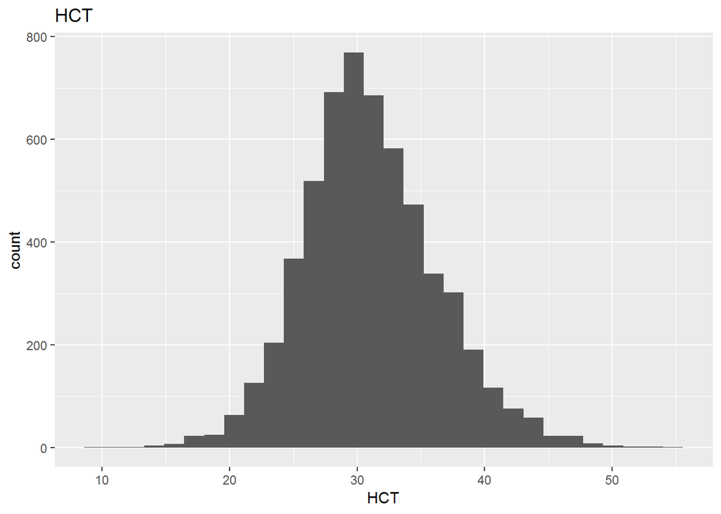

```r
check("BUN")
```

```
##       BUN
##  Min.   :  2.00
##  1st Qu.: 13.00
##  Median : 20.00
##  Mean   : 27.42
##  3rd Qu.: 34.00
##  Max.   :197.00
```

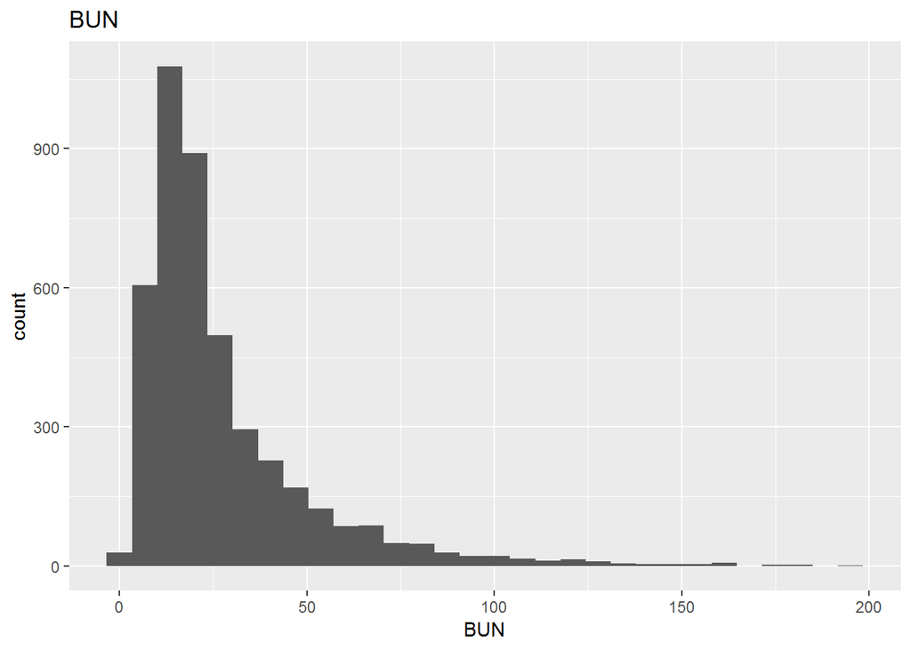

```r
check("Creatinine")
```

```
##    Creatinine
##  Min.   : 0.200
##  1st Qu.: 0.700
##  Median : 1.000
##  Mean   : 1.491
##  3rd Qu.: 1.500
##  Max.   :22.000
```

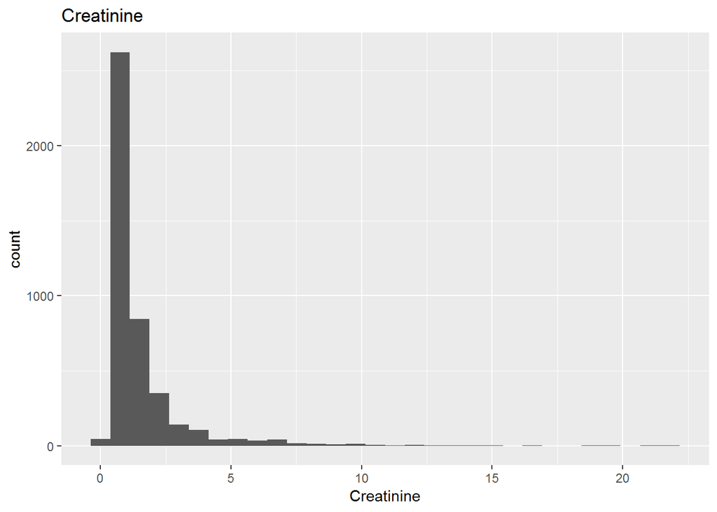

```r
check("Glucose")
```

```
##     Glucose
##  Min.   :  24.0
##  1st Qu.: 107.0
##  Median : 131.0
##  Mean   : 148.7
##  3rd Qu.: 167.0
##  Max.   :1143.0
```

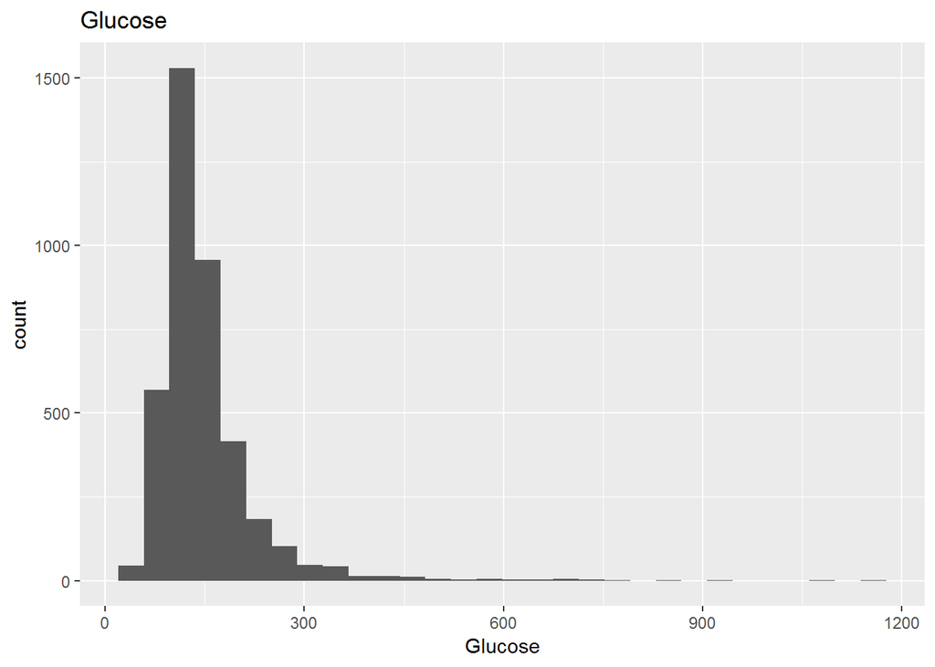

```r
check("HCO3")
```

```
##       HCO3
##  Min.   : 5.00
##  1st Qu.:20.00
##  Median :23.00
##  Mean   :22.73
##  3rd Qu.:26.00
##  Max.   :47.00
```

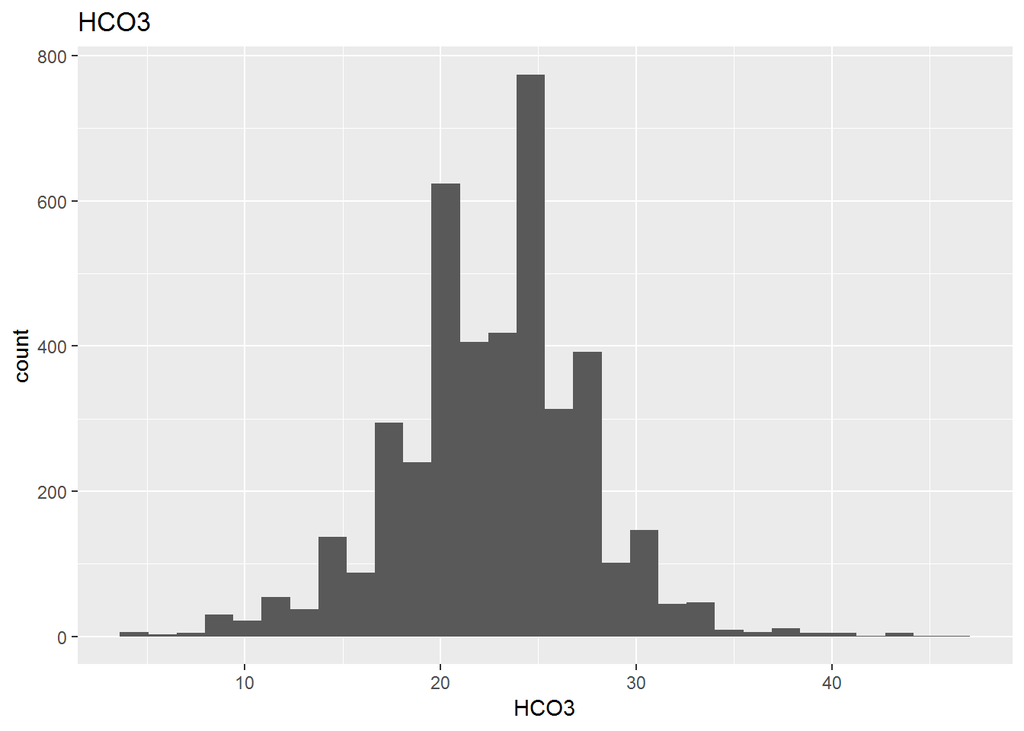

```r
check("Mg")
```

```
##        Mg
##  Min.   :0.600
##  1st Qu.:1.700
##  Median :2.000
##  Mean   :2.012
##  3rd Qu.:2.200
##  Max.   :9.900
```

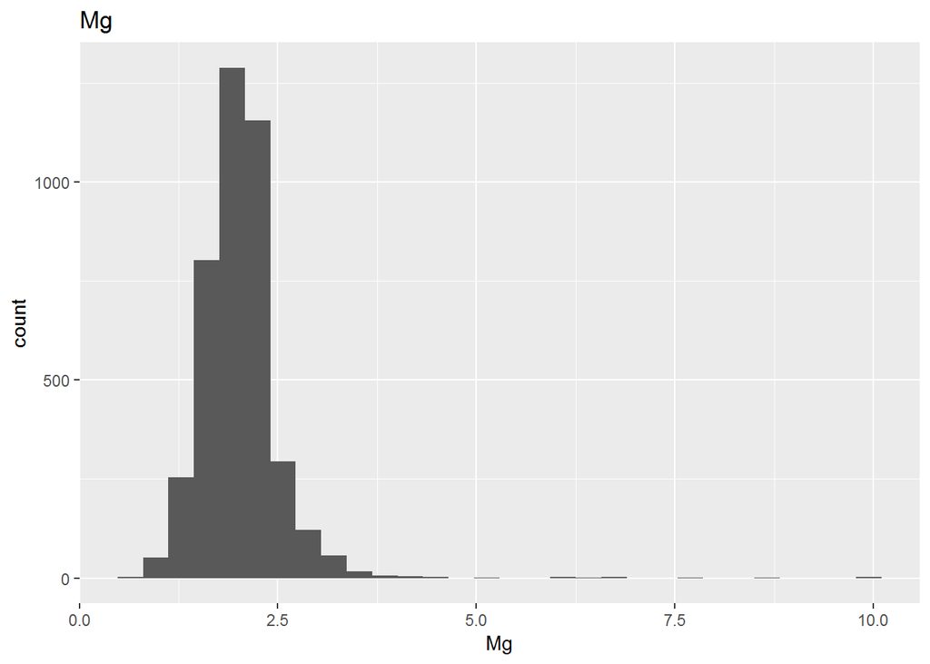

```r
check("Platelets")
```

```
##    Platelets
##  Min.   :   9.0
##  1st Qu.: 124.0
##  Median : 181.0
##  Mean   : 198.6
##  3rd Qu.: 248.0
##  Max.   :1047.0
```

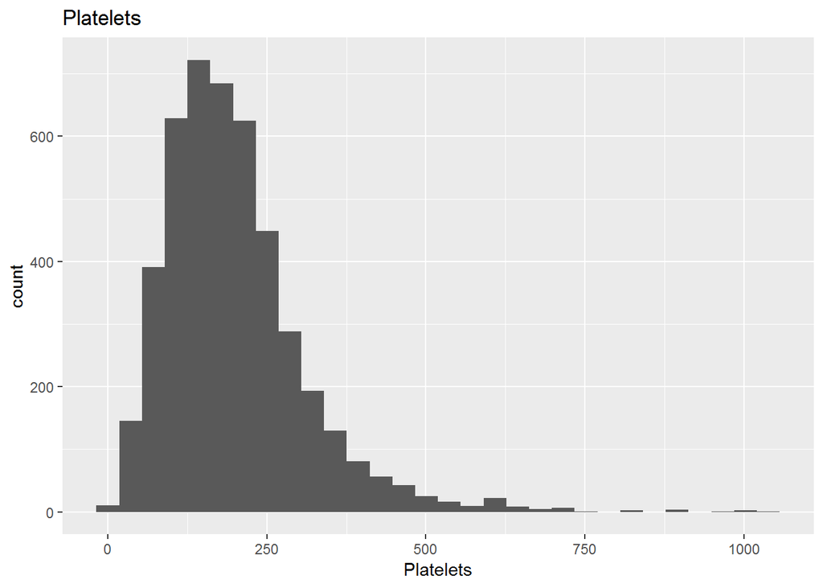

```r
check("K")
```

```
##        K
##  Min.   : 1.800
##  1st Qu.: 3.700
##  Median : 4.100
##  Mean   : 4.179
##  3rd Qu.: 4.500
##  Max.   :22.900
```

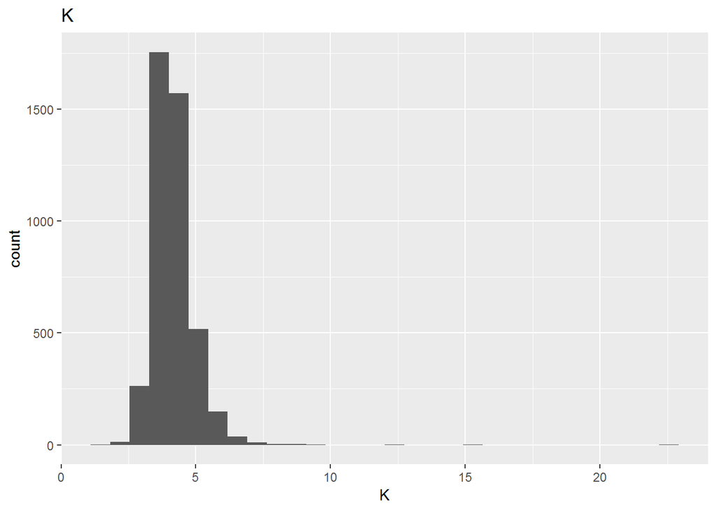

```r
check("Na")
```

```
##        Na
##  Min.   : 98.0
##  1st Qu.:136.0
##  Median :139.0
##  Mean   :139.2
##  3rd Qu.:142.0
##  Max.   :177.0
```

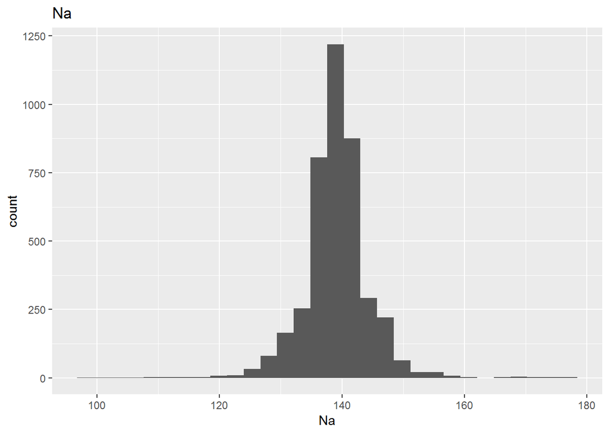

```r
check("WBC")
```

```
##       WBC
##  Min.   :  0.10
##  1st Qu.:  8.20
##  Median : 11.40
##  Mean   : 12.81
##  3rd Qu.: 15.60
##  Max.   :155.60
```

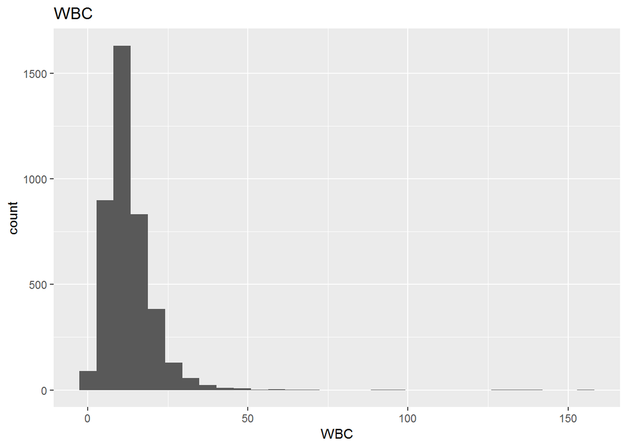

```r
check("pH")
```

```
##        pH
##  Min.   :  3.000
##  1st Qu.:  7.320
##  Median :  7.370
##  Mean   :  7.378
##  3rd Qu.:  7.420
##  Max.   :100.000
```

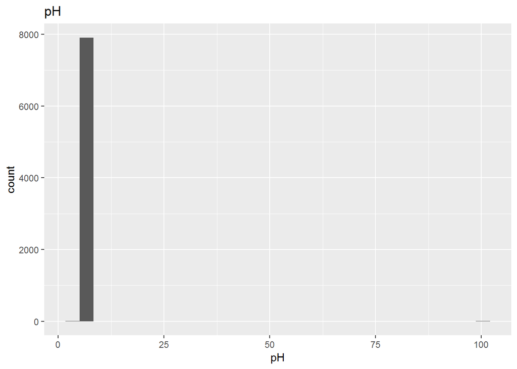

```r
check("PaCO2")
```

```
##      PaCO2
##  Min.   : 0.30
##  1st Qu.:35.00
##  Median :40.00
##  Mean   :40.88
##  3rd Qu.:45.00
##  Max.   :98.00
```

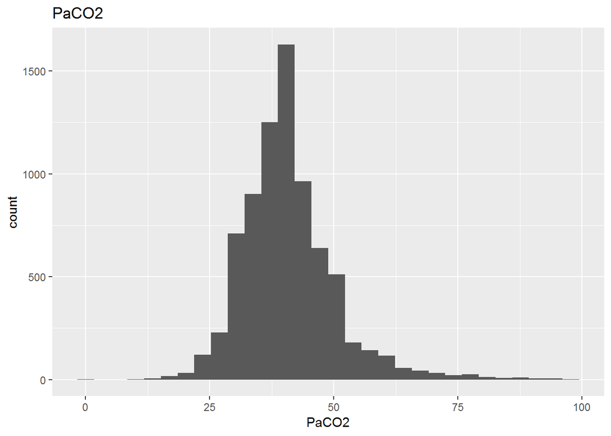

```r
check("PaO2")
```

```
##       PaO2
##  Min.   : 20.0
##  1st Qu.: 96.0
##  Median :134.0
##  Mean   :167.5
##  3rd Qu.:201.0
##  Max.   :500.0
```

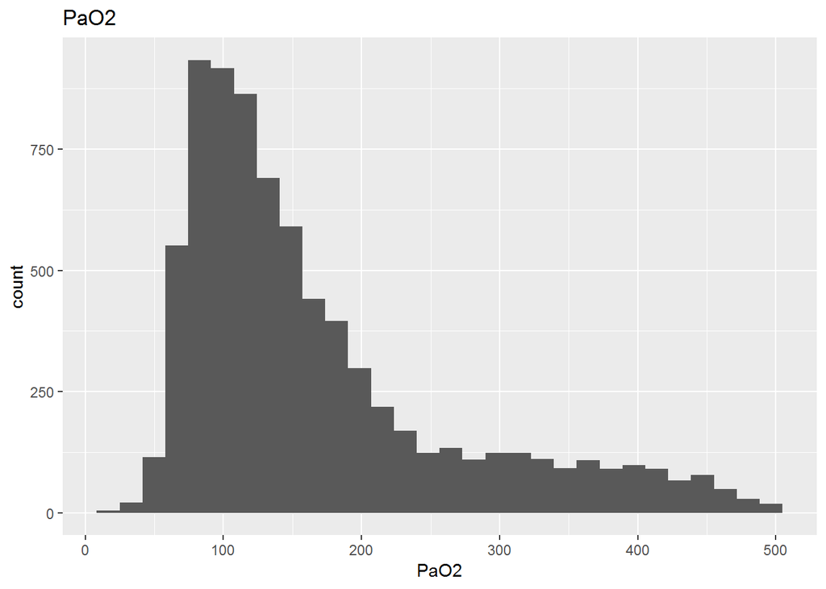

```r
check("DiasABP")
```

```
##     DiasABP
##  Min.   :  0.00
##  1st Qu.: 50.00
##  Median : 58.00
##  Mean   : 58.58
##  3rd Qu.: 66.00
##  Max.   :268.00
```

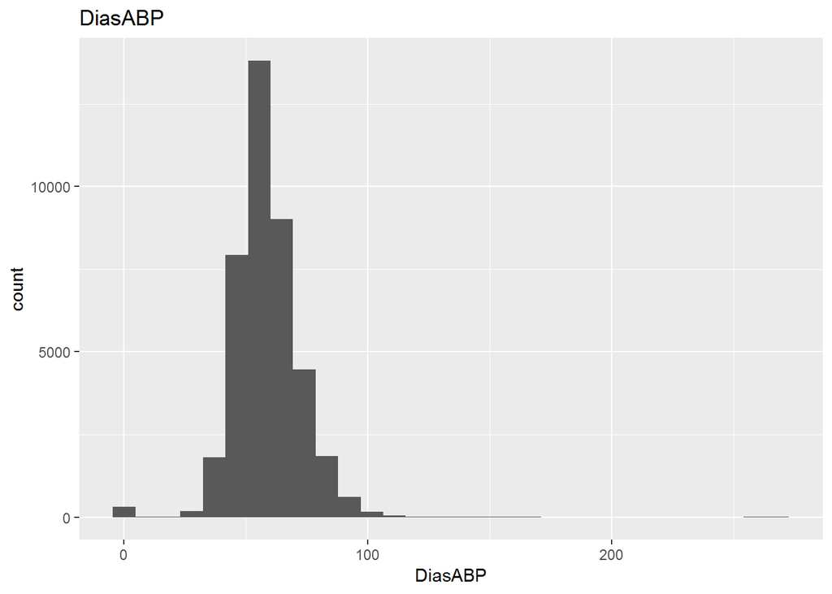

```r
check("FiO2")
```

```
##       FiO2
##  Min.   :0.2800
##  1st Qu.:0.4000
##  Median :0.5000
##  Mean   :0.5643
##  3rd Qu.:0.6000
##  Max.   :1.0000
```

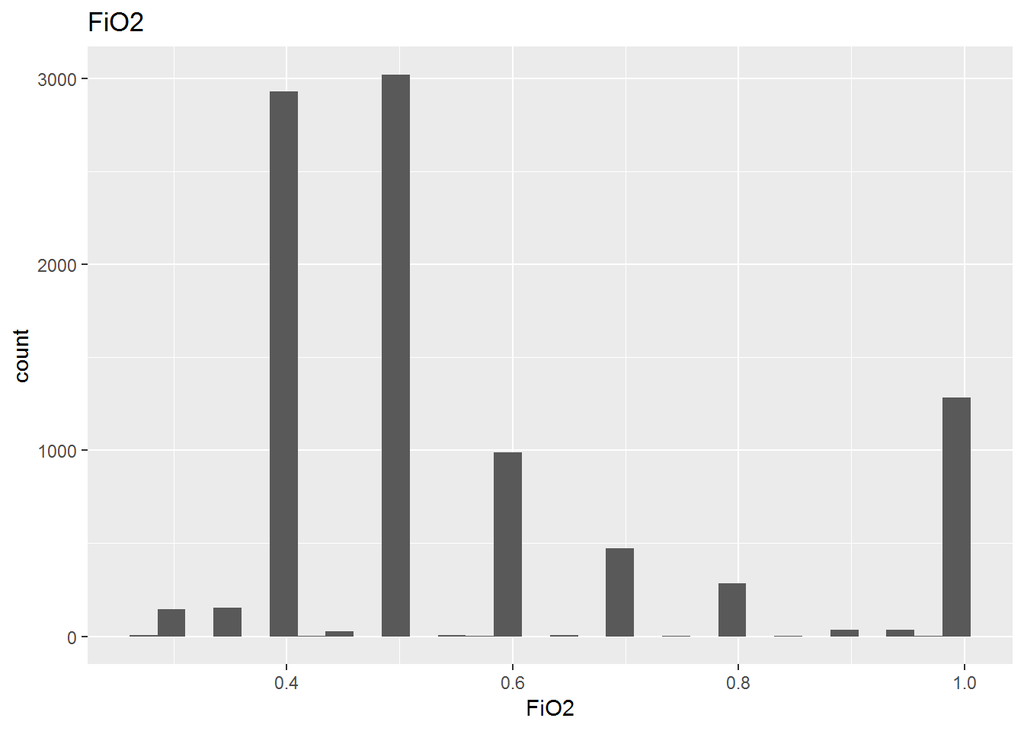

```
##       MAP
##  Min.   :  0.00
##  1st Qu.: 68.00
##  Median : 76.00
##  Mean   : 78.71
##  3rd Qu.: 87.00
##  Max.   :291.00
```

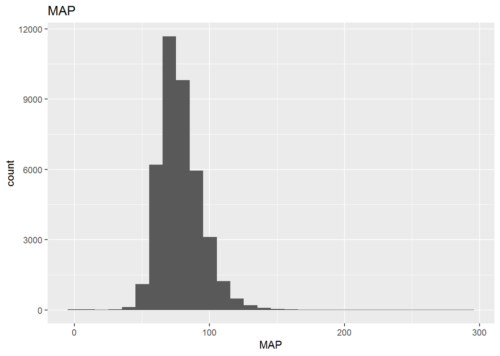

```r
check("MAP")
```

```r
check("MechVent")
```

```
##     MechVent
##  Min.   :1
##  1st Qu.:1
##  Median :1
##  Mean   :1
##  3rd Qu.:1
##  Max.   :1
```

[figure not shown]

```r
check("SysABP")
```

```
##      SysABP
##  Min.   :  0.0
##  1st Qu.:100.0
##  Median :114.0
##  Mean   :116.4
##  3rd Qu.:131.0
##  Max.   :295.0
```

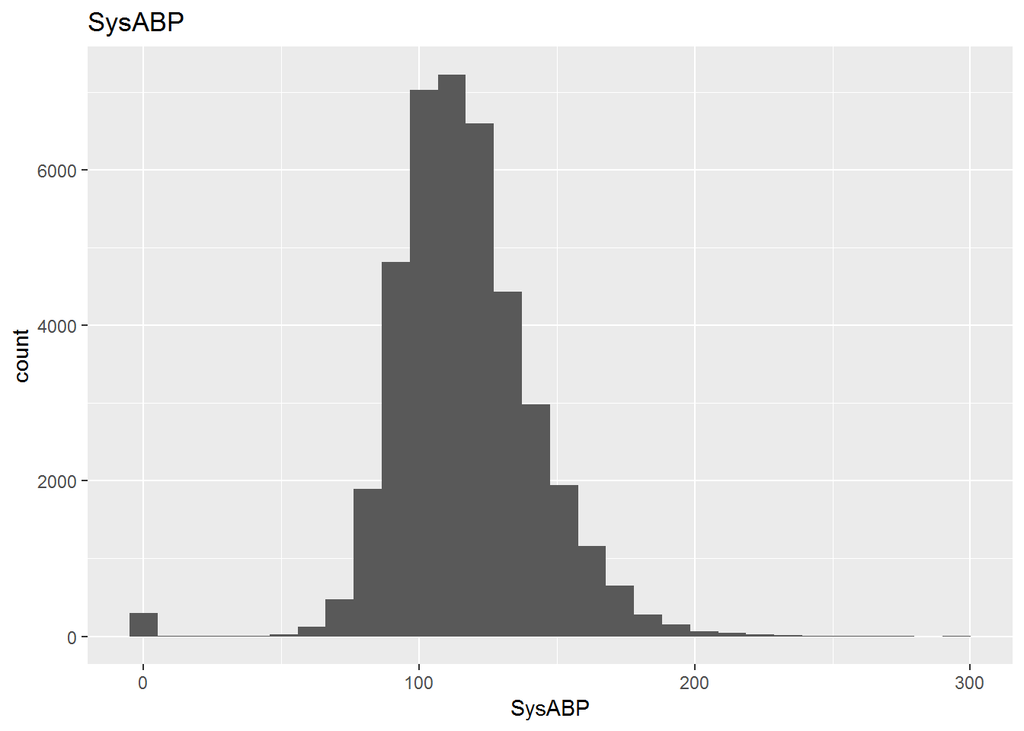